# Tarea 4 [Actividad grupal]: ggplot

```r
 ## grafica de dispersion con facetas en forma de filas y columnas, esto se debe a la posicion del ( ~ .) o (. ~) en el comando facet_grid()
```

Mira de nuevo el primer gráfico en facetas presentado en esta sección:

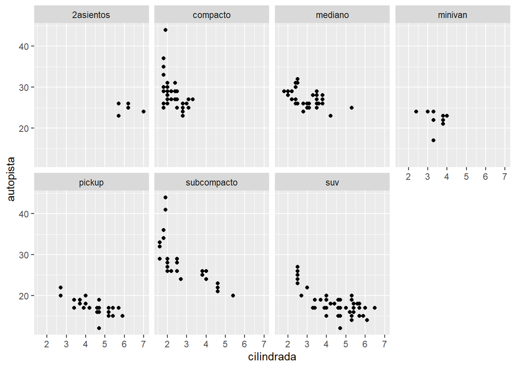

```r
ggplot(data = millas) +
  geom_point(mapping = aes(x = cilindrada, y = autopista)) +
  facet_wrap(~ clase, nrow = 2)
```

¿Cuáles son las ventajas de separar en facetas en lugar de aplicar una estética de color? ¿Cuáles son las desventajas? ¿Cómo cambiaría este balance si tuvieras un conjunto de datos más grande? - Lee ?facet_wrap. ¿Qué hace nrow? ¿Qué hace ncol? ¿Qué otras opciones controlan el diseño de los paneles individuales? ¿Por qué facet_grid() no tiene argumentos nrow y ncol? - Cuando usas facet_grid(), generalmente deberías poner la variable con un mayor número de niveles únicos en las columnas. ¿Por qué?

10.4 Parte 4: Objetos geométricos ¿Qué geom usarías para generar un gráfico de líneas? ¿Y para un diagrama de caja? ¿Y para un histograma? ¿Y para un gráfico de área?

```r
geom_line()
```

```
## geom_line: na.rm = FALSE, orientation = NA
## stat_identity: na.rm = FALSE
## position_identity
```

```r
geom_boxplot()
```

```
## geom_boxplot: outlier.colour = NULL, outlier.fill = NULL, outlier.shape = 19, outlier.size = 1.5, outlier.stroke = 0.5, outlier.alpha = NULL, notch = FALSE, notchwidth = 0.5, varwidth = FALSE, na.rm = FALSE, orientation = NA
## stat_boxplot: na.rm = FALSE, orientation = NA
## position_dodge2
```

```r
geom_histogram()
```

```
## geom_bar: na.rm = FALSE, orientation = NA
## stat_bin: binwidth = NULL, bins = NULL, na.rm = FALSE, orientation = NA, pad = FALSE
## position_stack
```

```r
geom_area()
```

```
## geom_area: na.rm = FALSE, orientation = NA, outline.type = upper
## stat_identity: na.rm = FALSE
## position_stack
```

Ejecuta este código en tu mente y predice cómo se verá el output. Luego, ejecuta el código en R y verifica tus predicciones.

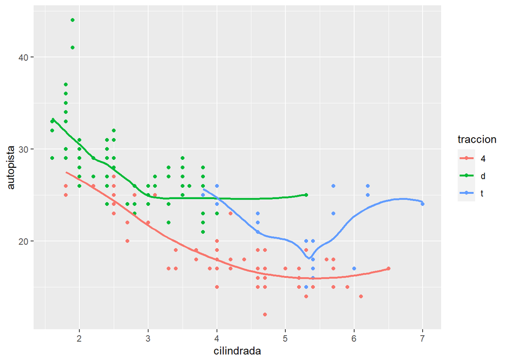

```r
ggplot(data = millas, mapping = aes(x = cilindrada, y = autopista, color = traccion)) +
  geom_point() +
  geom_smooth(se = FALSE)
```

¿Qué muestra show.legend = FALSE? ¿Qué pasa si lo quitas? ¿Por qué crees que lo utilizamos antes en el capítulo?

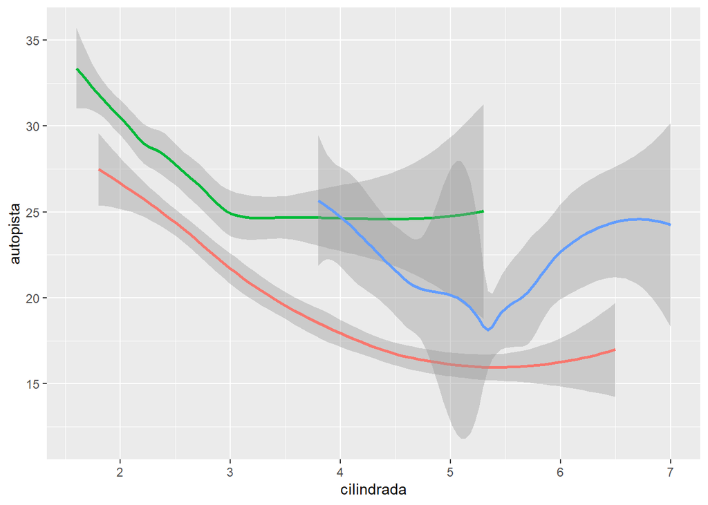

```r
# Sin leyenda:
ggplot(data = millas) +
  geom_smooth(
    mapping = aes(x = cilindrada, y = autopista, colour = traccion),
    show.legend = FALSE)
```

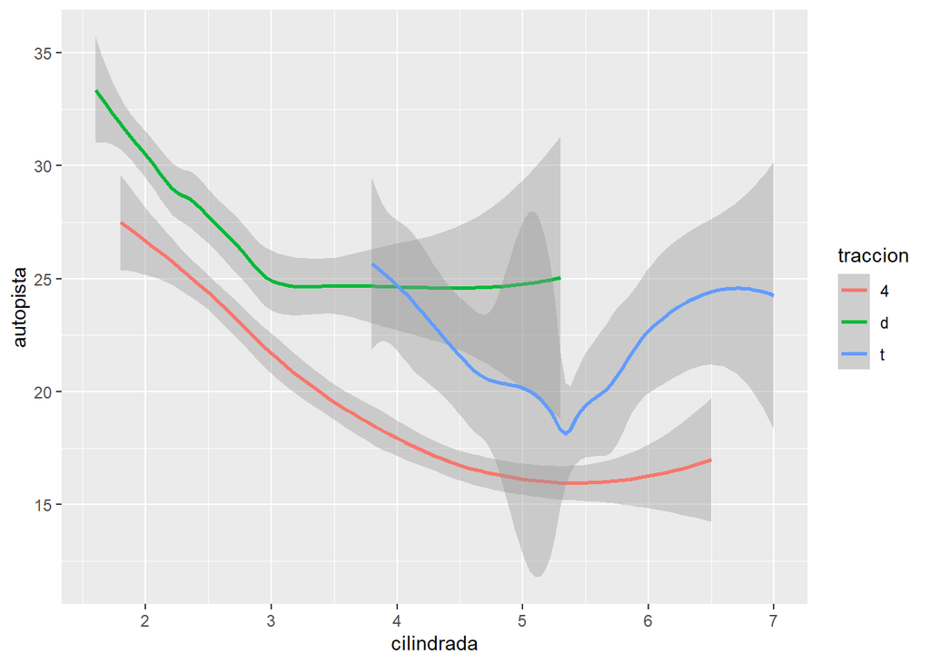

```r
# Con leyenda:
ggplot(data = millas) +
  geom_smooth(
    mapping = aes(x = cilindrada, y = autopista, colour = traccion),
    show.legend = TRUE
  )
```

¿Qué hace el argumento se en geom_smooth()?

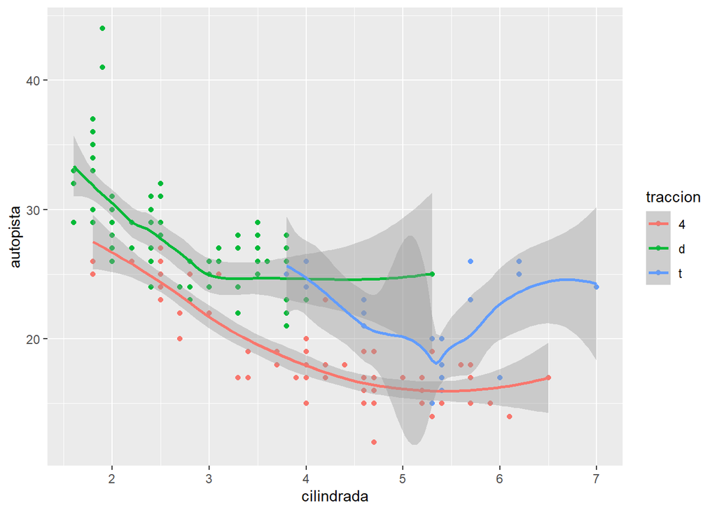

```r
ggplot(data = millas, mapping = aes(x = cilindrada, y = autopista, colour = traccion)) +
  geom_point() +
  geom_smooth(se = TRUE) #agrega el sombreado en las bandas de error
```

¿Se verán distintos estos gráficos? ¿Por qué sí o por qué no?

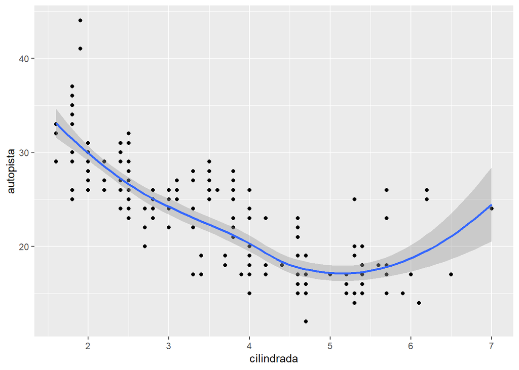

```r
ggplot(data = millas, mapping = aes(x = cilindrada, y = autopista)) +
  geom_point() +
  geom_smooth()
```

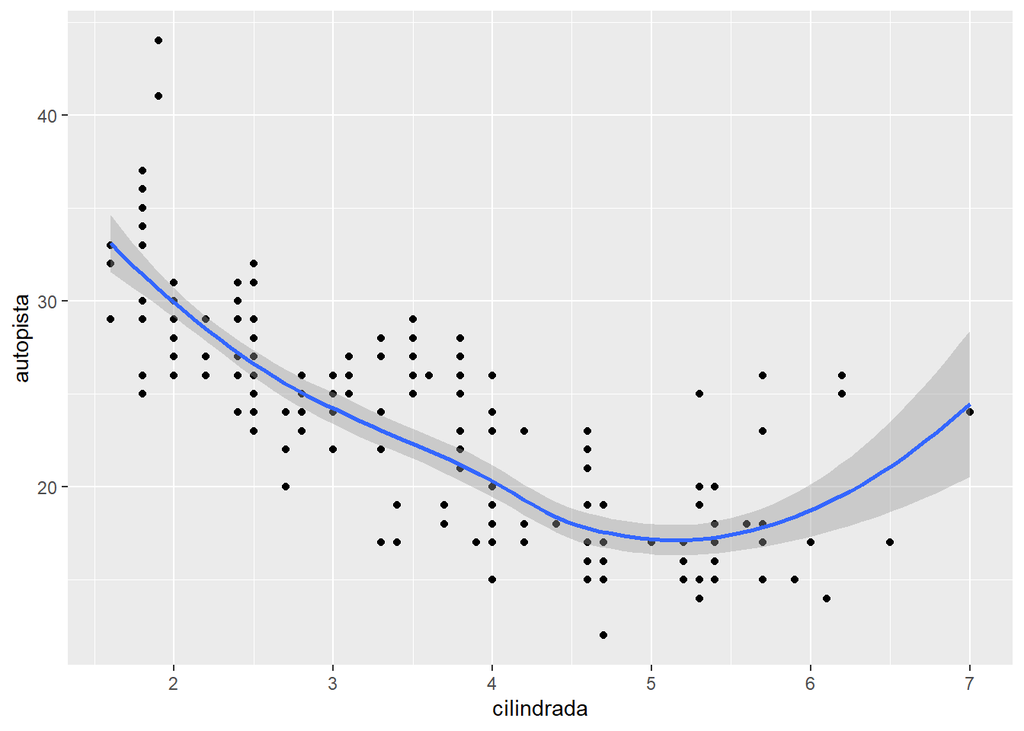

```r
ggplot() +
  geom_point(data = millas, mapping = aes(x = cilindrada, y = autopista)) +
  geom_smooth(data = millas, mapping = aes(x = cilindrada, y = autopista))
```

```r
# la diferencia esta en como llamar los parametros.
```

Recrea el código R necesario para generar los siguientes gráficos:

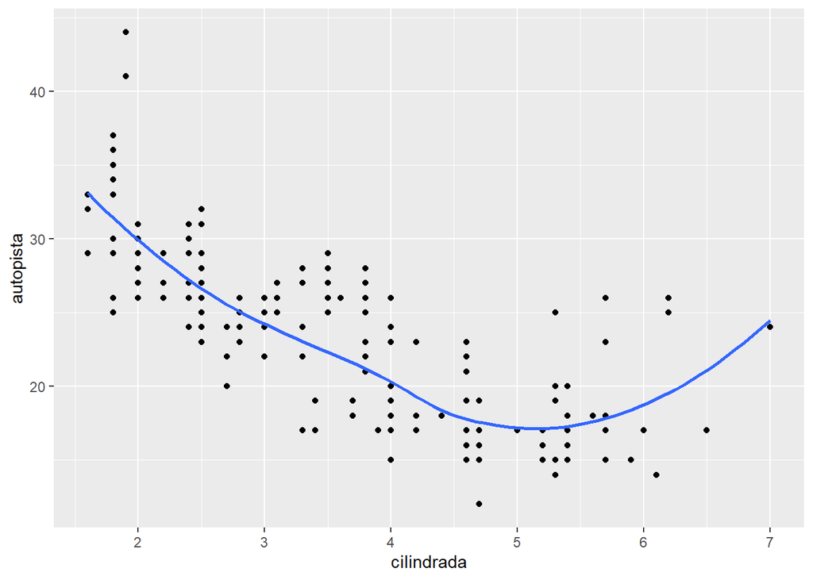

```r
# Gráfico 1
ggplot(data = millas, mapping = aes(x = cilindrada, y = autopista)) +
  geom_point() +
  geom_smooth(se = FALSE)
```

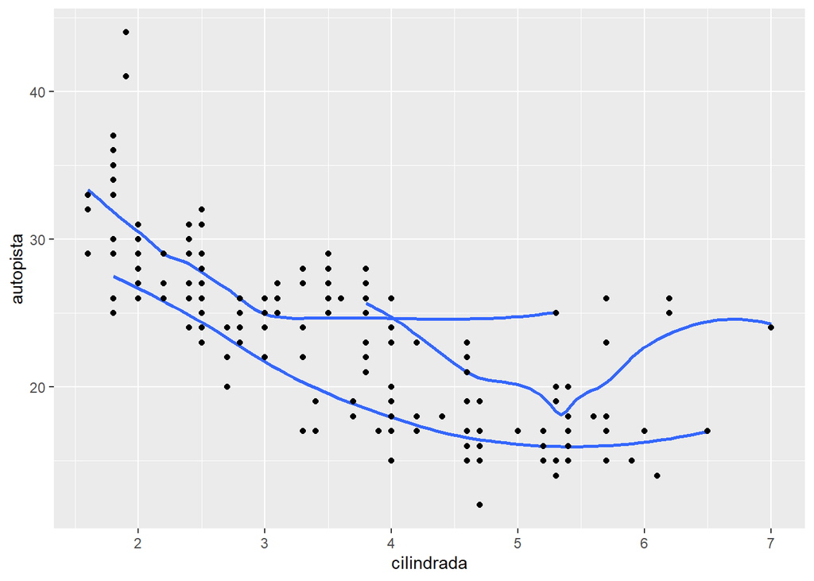

```r
# Gráfico 2

ggplot(data = millas, mapping = aes(x = cilindrada, y = autopista)) +
  geom_smooth(aes(group = traccion), se = FALSE) +
  geom_point()
```

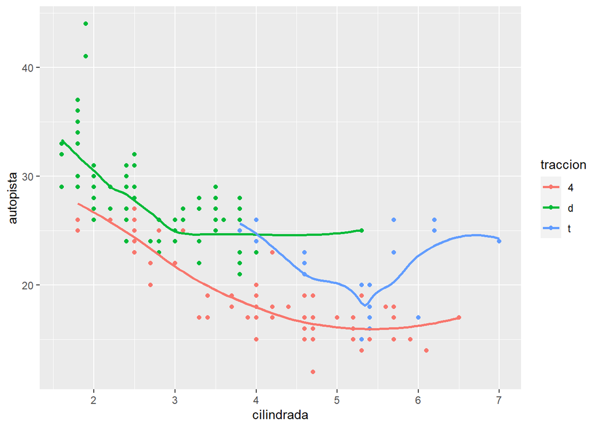

```r
# Gráfico 3

ggplot(data = millas, mapping = aes(x = cilindrada, y = autopista, color = traccion)) +
  geom_point() +
  geom_smooth(se = FALSE)
```

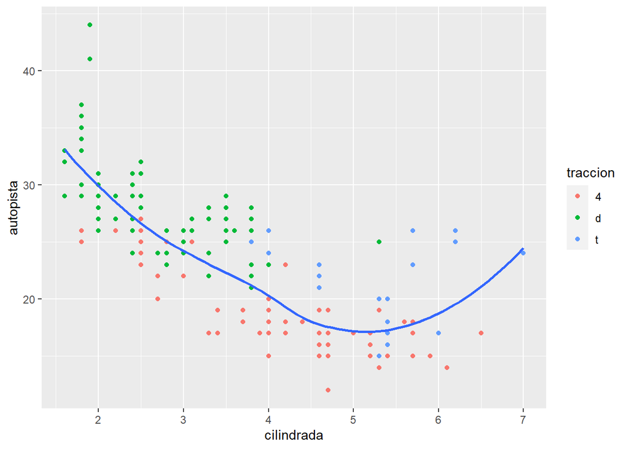

```r
# Gráfico 4

ggplot(data = millas, mapping = aes(x = cilindrada, y = autopista)) +
  geom_point(aes(color = traccion)) +
  geom_smooth(se = FALSE)
```

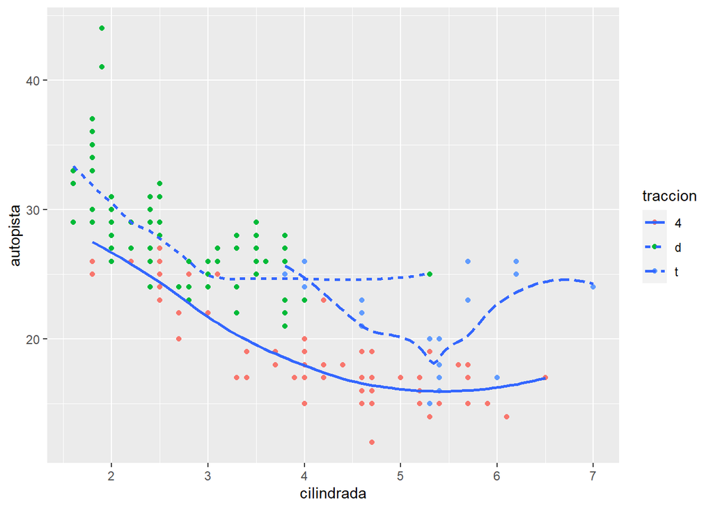

```r
# Gráfico 5

ggplot(data = millas, mapping = aes(x = cilindrada, y = autopista)) +
  geom_point(aes(color = traccion)) +
  geom_smooth(aes(linetype = traccion), se = FALSE)
```

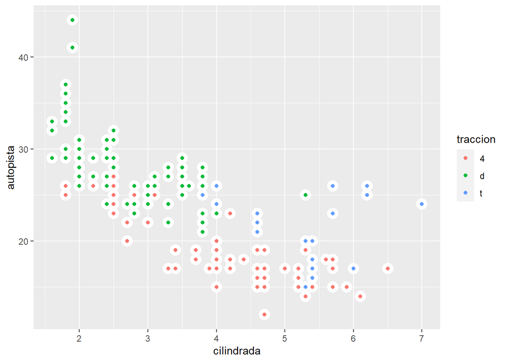

```r
# Gráfico 6

ggplot(data = millas, mapping = aes(x = cilindrada, y = autopista)) +
  geom_point(size = 5, colour = "white") +
  geom_point(aes(colour = traccion))
```

10.5 Parte 5: Gráficos estadísticos ¿Cuál es el geom predeterminado asociado con stat_summary()? ¿Cómo podrías reescribir el gráfico anterior para usar esa función geom en lugar de la función stat?

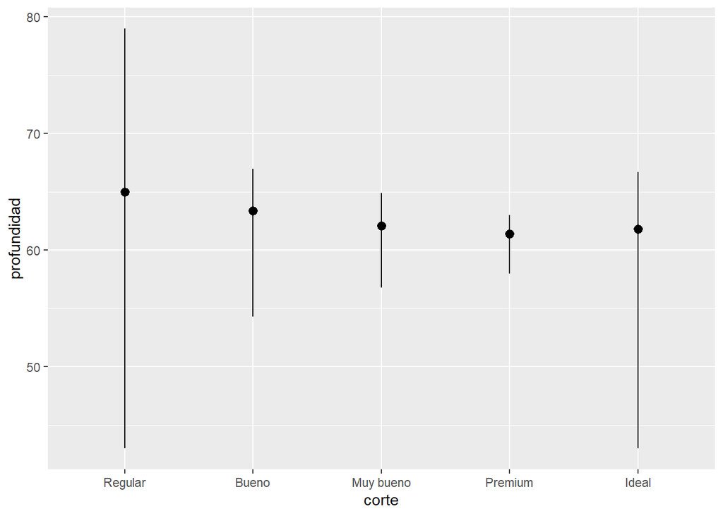

```r
ggplot(data = diamantes) +
  stat_summary(
    mapping = aes(x = corte, y = profundidad),
    fun.ymin = min,
    fun.ymax = max,
    fun.y = median
  )
```

La geometría por defecto para stat_summary() es geom_pointrange().

El estadístico por defecto para geom_pointrange() es identity() pero se puede incluir el argumento stat = “summary” para usar stat_summary() en lugar de stat_identity().

```
## No summary function supplied, defaulting to `mean_se()`
```

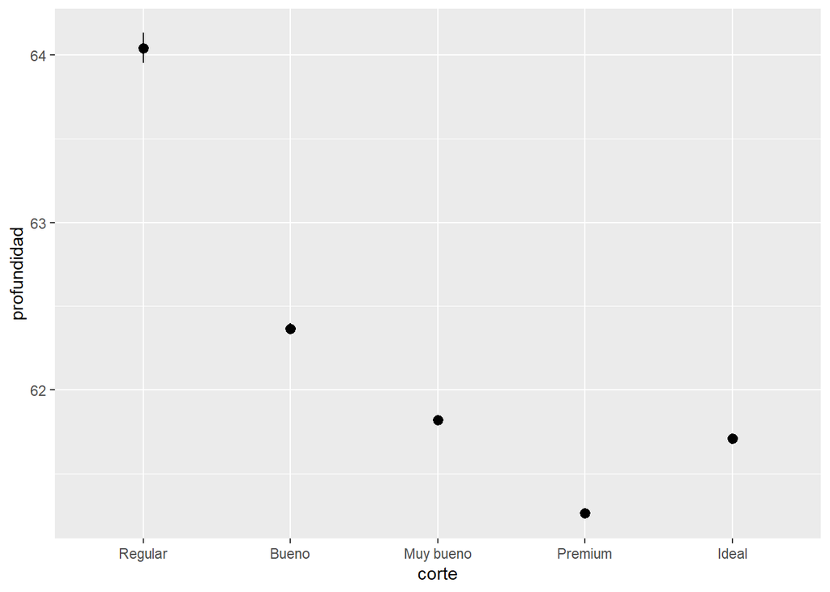

```r
ggplot(data = diamantes) +
  geom_pointrange(
    mapping = aes(x = corte, y = profundidad),
    stat = "summary"
  )
```

```
## No summary function supplied, defaulting to `mean_se()`
```

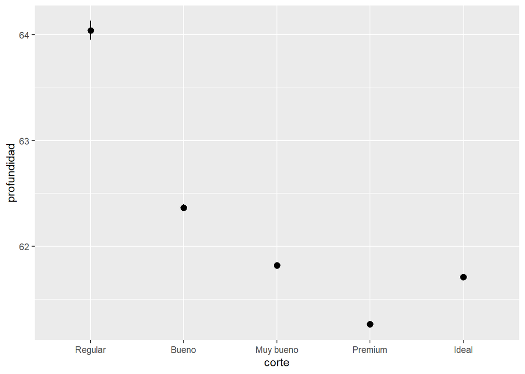

```r
ggplot(data = diamantes) +
  geom_pointrange(
    mapping = aes(x = corte, y = profundidad),
    stat = "summary",
    fun.ymin = min,
    fun.ymax = max,
    fun.y = median
  )
```

¿Qué hace geom_col()? ¿En qué se diferencia de geom_bar()?

El estadístico por defecto en geom_col() es distinto de geom_bar().

geom_col() usa stat_identity(), que deja los datos sin transformar.

geom_col() espera que los datos contengan los valores de x y los valores de y que representan la altura de las columnas.

# La mayoría de los geoms y las transformaciones estadísticas vienen en pares que casi siempre se usan en conjunto. Lee la documentación y haz una lista de todos los pares. ¿Qué tienen en común?

Las siguiente tabla contienen los pares entre geometrías y estadísticos que se usan en conjunto.

[output not shown]

Tabla: Geometrías y estadísticos complementarios

Los nombres tienen a ser similares, por ejemplo `geom_smooth()` y `stat_smooth()`, aunque hay casos como `geom_bar()` y `stat_count()`.

La mayoría de las geometrías usa por defecto el estadístico que le corresponde en la tabla anterior. Recíprocamente, la mayoría de los estadísticos usan por defecto la geometría que le corresponde en la tabla anterior.

Las siguientes tablas contienen las geometrías y estadísticos en [ggplot2](https://ggplot2.tidyverse.org/reference/).

| geometría | estadístico por defecto | documentación conjunta |
| --- | --- | --- |
| `geom_abline()` |  |  |
| `geom_hline()` |  |  |
| `geom_vline()` |  |  |
| `geom_bar()` | `stat_count()` | x |
| `geom_col()` |  |  |
| `geom_bin2d()` | `stat_bin_2d()` | x |
| `geom_blank()` |  |  |
| `geom_boxplot()` | `stat_boxplot()` | x |
| `geom_countour()` | `stat_countour()` | x |
| `geom_count()` | `stat_sum()` | x |
| `geom_density()` | `stat_density()` | x |
| `geom_density_2d()` | `stat_density_2d()` | x |
| `geom_dotplot()` |  |  |
| `geom_errorbarh()` |  |  |
| `geom_hex()` | `stat_hex()` | x |
| `geom_freqpoly()` | `stat_bin()` | x |
| `geom_histogram()` | `stat_bin()` | x |
| `geom_crossbar()` |  |  |
| `geom_errorbar()` |  |  |
| `geom_linerange()` |  |  |
| `geom_pointrange()` |  |  |
| `geom_map()` |  |  |
| `geom_point()` |  |  |
| `geom_map()` |  |  |
| `geom_path()` |  |  |
| `geom_line()` |  |  |
| `geom_step()` |  |  |
| `geom_point()` |  |  |
| `geom_polygon()` |  |  |
| `geom_qq_line()` | `stat_qq_line()` | x |
| `geom_qq()` | `stat_qq()` | x |
| `geom_quantile()` | `stat_quantile()` | x |
| `geom_ribbon()` |  |  |
| `geom_area()` |  |  |
| `geom_rug()` |  |  |
| `geom_smooth()` | `stat_smooth()` | x |
| `geom_spoke()` |  |  |
| `geom_label()` |  |  |
| `geom_text()` |  |  |
| `geom_raster()` |  |  |
| `geom_rect()` |  |  |
| `geom_tile()` |  |  |
| `geom_violin()` | `stat_ydensity()` | x |
| `geom_sf()` | `stat_sf()` | x |

Tabla: ggplot2 capas de geometrías y sus estadísticos por defecto.

| estadístico | geometría por defecto | documentación conjunta |
| --- | --- | --- |
| `stat_ecdf()` | `geom_step()` |  |
| `stat_ellipse()` | `geom_path()` |  |
| `stat_function()` | `geom_path()` |  |
| `stat_identity()` | `geom_point()` |  |
| `stat_summary_2d()` | `geom_tile()` |  |
| `stat_summary_hex()` | `geom_hex()` |  |
| `stat_summary_bin()` | `geom_pointrange()` |  |
| `stat_summary()` | `geom_pointrange()` |  |
| `stat_unique()` | `geom_point()` |  |
| `stat_count()` | `geom_bar()` | x |
| `stat_bin_2d()` | `geom_tile()` | x |
| `stat_boxplot()` | `geom_boxplot()` | x |
| `stat_countour()` | `geom_contour()` | x |
| `stat_sum()` | `geom_point()` | x |
| `stat_density()` | `geom_area()` | x |
| `stat_density_2d()` | `geom_density_2d()` | x |
| `stat_bin_hex()` | `geom_hex()` | x |
| `stat_bin()` | `geom_bar()` | x |
| `stat_qq_line()` | `geom_path()` | x |
| `stat_qq()` | `geom_point()` | x |
| `stat_quantile()` | `geom_quantile()` | x |
| `stat_smooth()` | `geom_smooth()` | x |
| `stat_ydensity()` | `geom_violin()` | x |
| `stat_sf()` | `geom_rect()` | x |

Tabla: ggplot2 capas de estadísticos y sus geometrías por defecto.

¿Qué variables calcula stat_smooth()? ¿Qué parámetros controlan su comportamiento?

La función `stat_smooth()` calcula las siguientes variables:

- `y`: valor predicho
- `ymin`: menor valor del intervalo de confianza
- `ymax`: mayor valor del intervalo de confianza
- `se`: error estándar

La sección “Computed Variables” en la documentación de `stat_smooth()` contiene estas variables.

Los parámetros que controlan `stat_smooth()` incluyen

- `method`: cuál método utilizar
- `formula`: las fórmulas, al igual que `method`, determinan cómo se hará el cálculo del intervalo de confianza y los argumentos adicionales que se requieran.
- `na.rm`: si acaso se eliminarán los casos perdidos

¿Cual es el problema con este grafico?Â¿Como podrias mejorarlo?

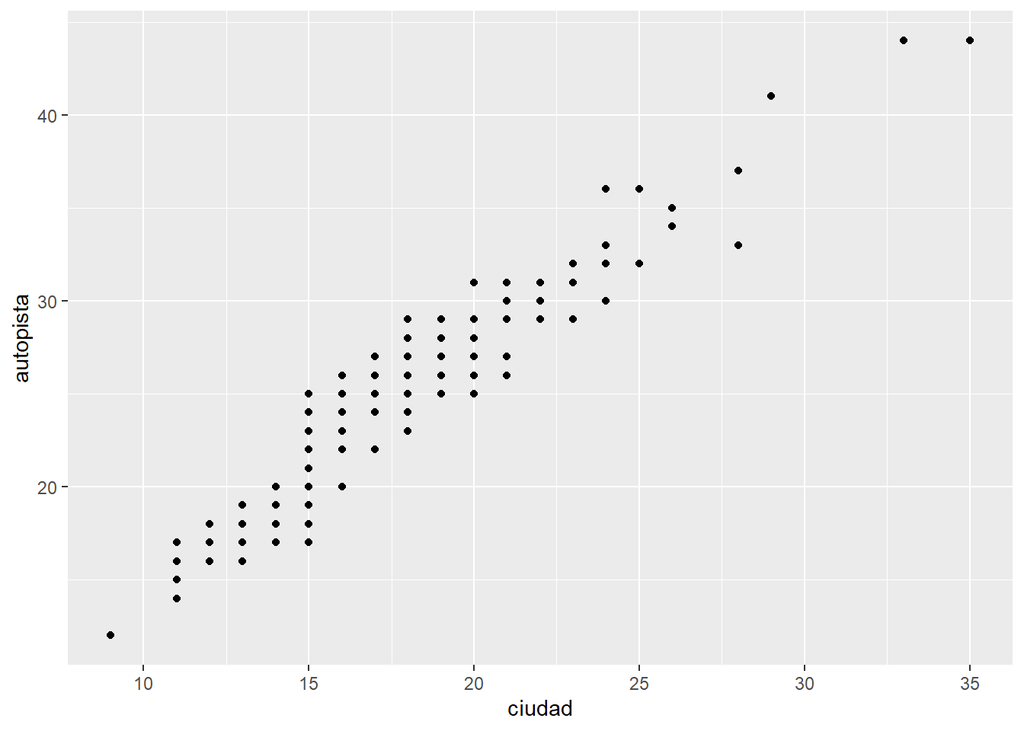

```r
ggplot(data = millas, mapping = aes(x = ciudad, y = autopista)) +
geom_point()
```

Existe superposicion ya que hay multiples observaciones para cada combinacion de `ciudad` y `autopista`. Se puede mejorar el grafico usando el argumento de distorsion y asi reducir la superposicion.

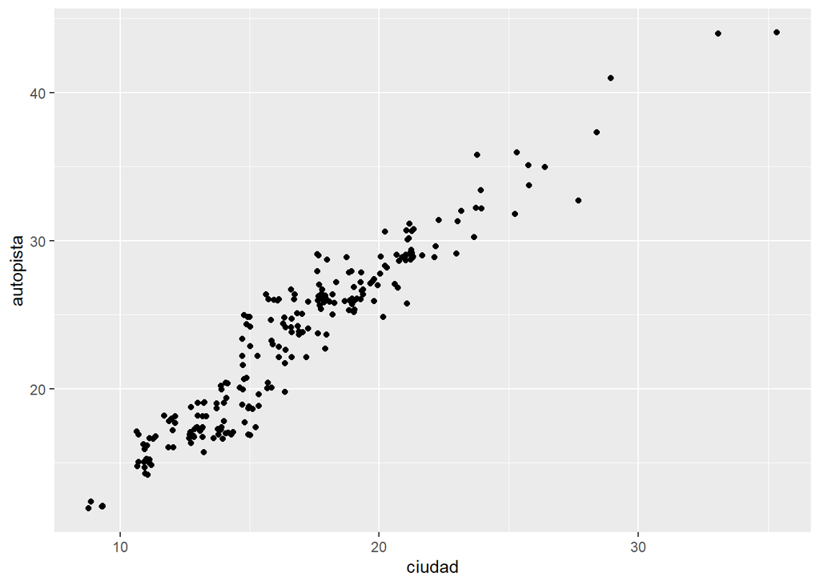

```r
ggplot(data = millas, mapping = aes(x = ciudad, y = autopista)) +
  geom_point(position = "jitter")
```

La relacion entre `ciudad` y `autopista` es clara, incluso sin el argumento de distorsion, que en este caso deja en claro donde se concentran las observaciones.

Â¿Que parametros de `geom_jitter()` controlan la cantidad de ruido? A partir de la documentacion de [`geom_jitter()`](https://ggplot2.tidyverse.org/reference/geom_jitter.html), existen dos argumentos:

Los valores por defecto de `width` y `height` introducen ruido en ambas direcciones.

Asi se ve el grafico con las opciones por defecto.

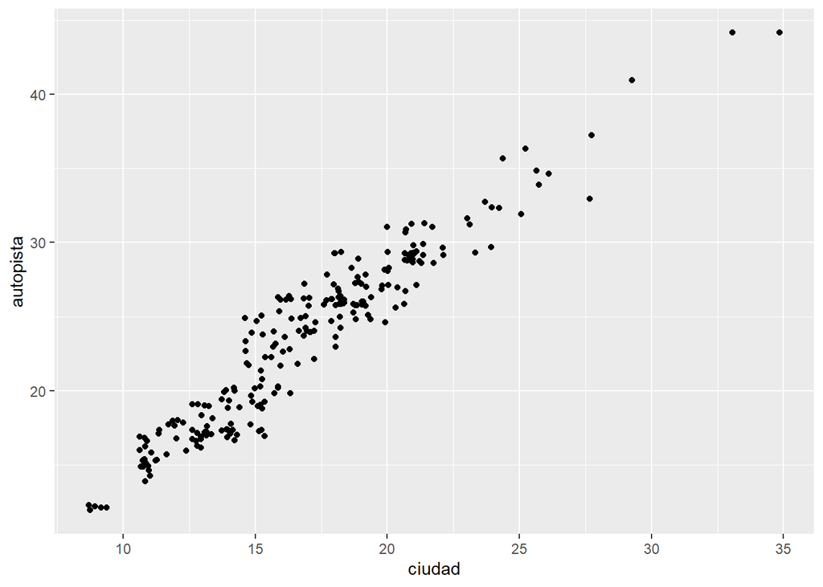

```r
ggplot(data = millas, mapping = aes(x = ciudad, y = autopista)) +
  geom_point(position = position_jitter())
```

Con `width = 0` se elimina la distorsion horizontal.

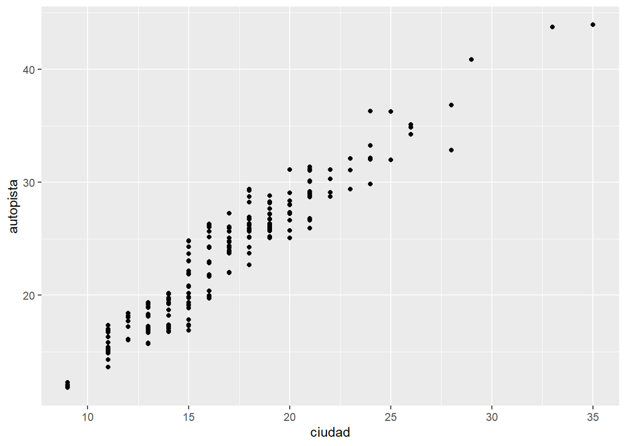

```r
ggplot(data = millas, mapping = aes(x = ciudad, y = autopista)) +
  geom_jitter(width = 0)
```

Con `width = 20` se agrega mucha distorsion.

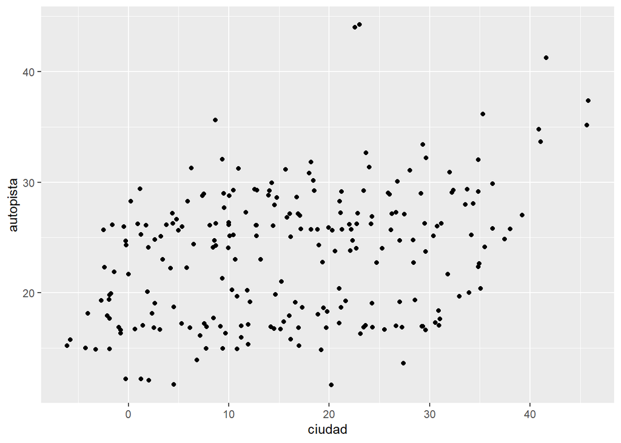

```r
ggplot(data = millas, mapping = aes(x = ciudad, y = autopista)) +
  geom_jitter(width = 20)
```

Es analogo para `height`.

Hay que notar que `width` y `height` se expresan en las mismas unidades que los datos, por lo que `height = 1` o `width = 1` corresponden a diferentes valores relativos de distorsiÃ³n dependiendo de las escalas de `x` e `y`.

Compara y contrasta `geom_jitter()` con `geom_count()` `geom_jitter()` agrega una variacion al azar a los puntos del grafico, es decir que distorsiona la ubicacion de los puntos en el grafico. Este metodo reduce la superposicion ya que es poco probable que al mover los puntos al azar estos queden en la misma ubicacion. Sin embargo, el problema de reducir la superposicion es que se distorsionan los valores mostrados de `x` e `y`.

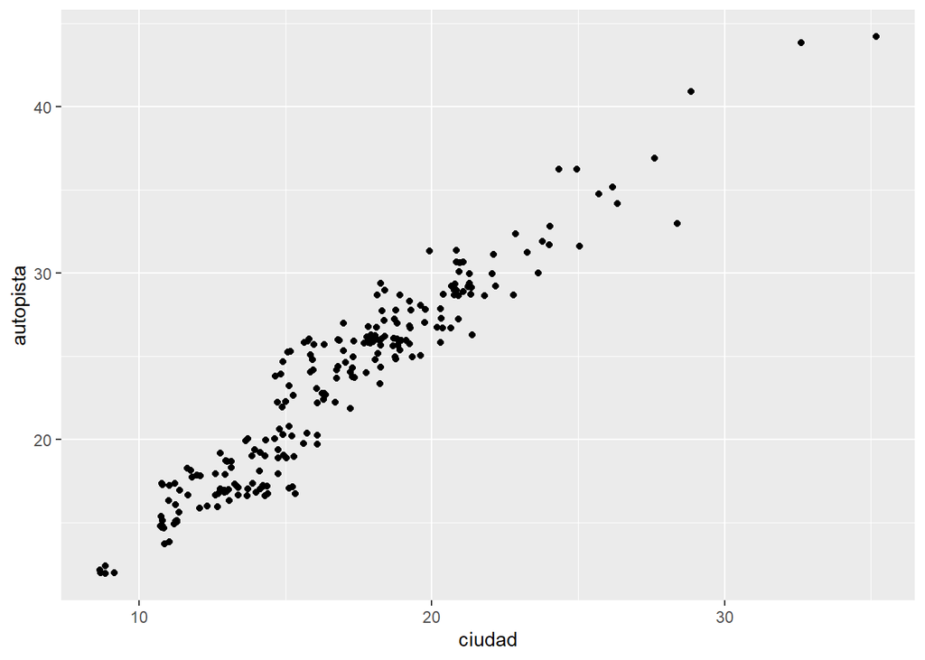

```r
ggplot(data = millas, mapping = aes(x = ciudad, y = autopista)) +
  geom_jitter()
```

`geom_count()` cambia el tamaÃ±o de los puntos relativo a la cantidad de observaciones. Las combinaciones de `x` e `y` con mas observaciones tendran un mayor tamaño. Esto no distorsiona los valores, pero tiene el problema de que el tamaño de los puntos puede generar superposicion si los puntos son cercanos.

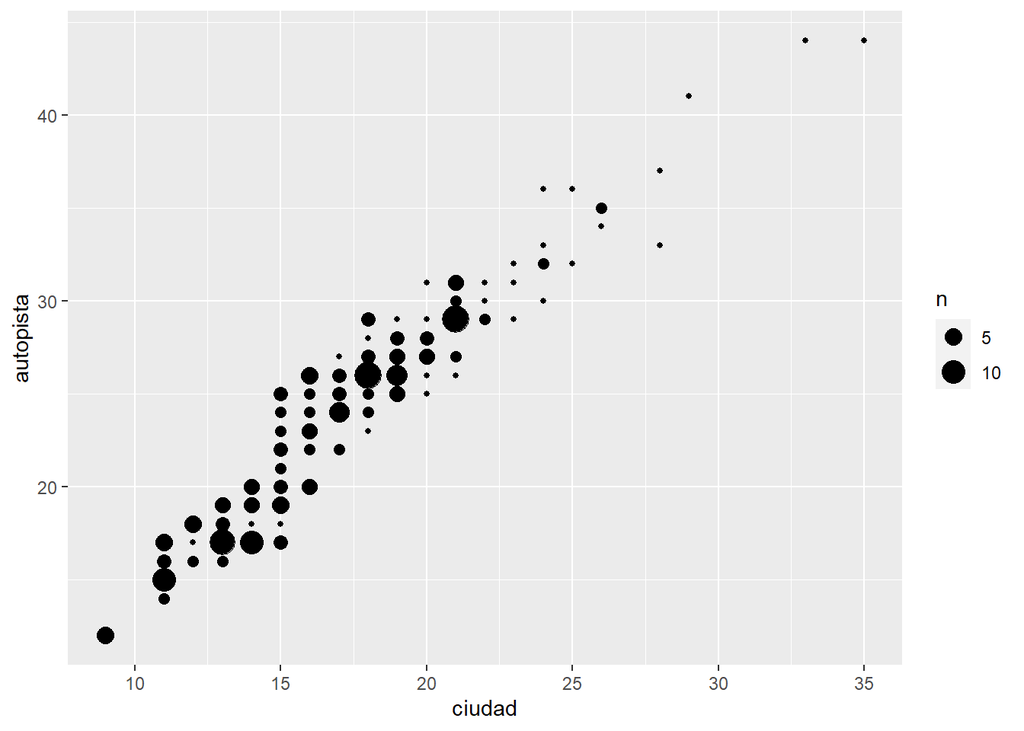

```r
ggplot(data = millas, mapping = aes(x = ciudad, y = autopista)) +
  geom_count()
```

Por ejemplo, `geom_count()` puede ser menos legible que `geom_jitter()` si se agrega un argumento de color.

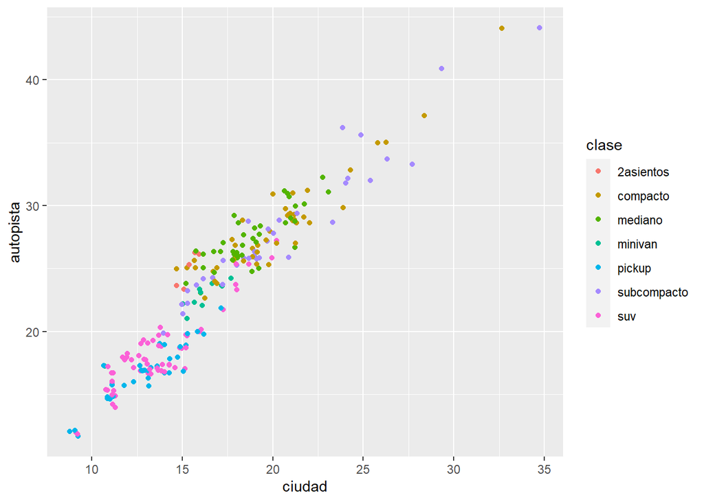

```r
ggplot(data = millas, mapping = aes(x = ciudad, y = autopista, color = clase)) +
  geom_jitter()
```

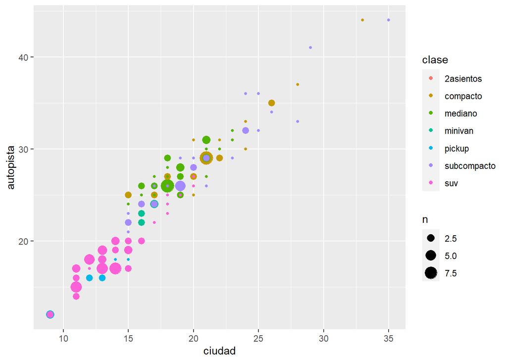

```r
ggplot(data = millas, mapping = aes(x = ciudad, y = autopista, color = clase)) +
  geom_count()
```

Este ejemplo muestra que no existe una solucion universal. El coste y beneficio de cada enfoque depende de la estructura de los datos y del objetivo.

¿Cual es el ajuste de posicion predeterminado de `geom_boxplot()`? Crea una visualizacion del conjunto de datos de `millas` que lo demuestre.

La posicion por defecto para `geom_boxplot()` es `"dodge2"`, que es un atajo de `position_dodge2`.

Este ajuste no cambia la posicion vertical pero mueve las geometrias horizontalmente para evitar la superposicion.

Consulta la documentacion de [`position_dodge2()`](https://ggplot2.tidyverse.org/reference/position_dodge.html) para los detalles especificos.

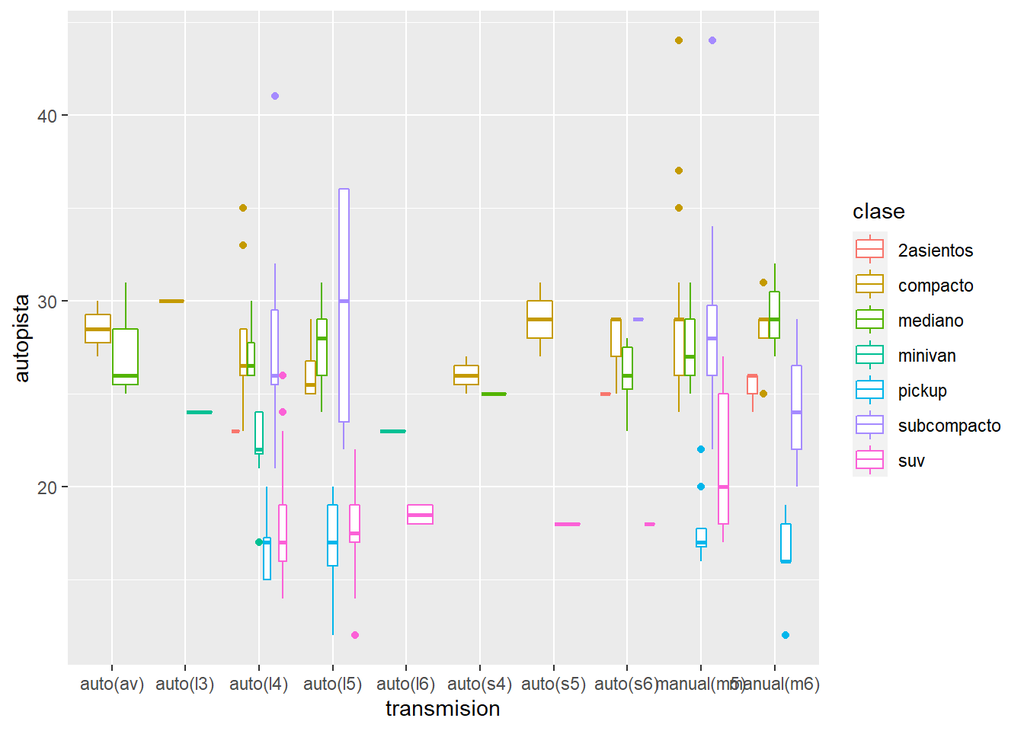

```r
ggplot(data = millas, aes(x = transmision, y = autopista, colour = clase)) +
  geom_boxplot()
```

Si se usa `position_identity()` habra superposicion.

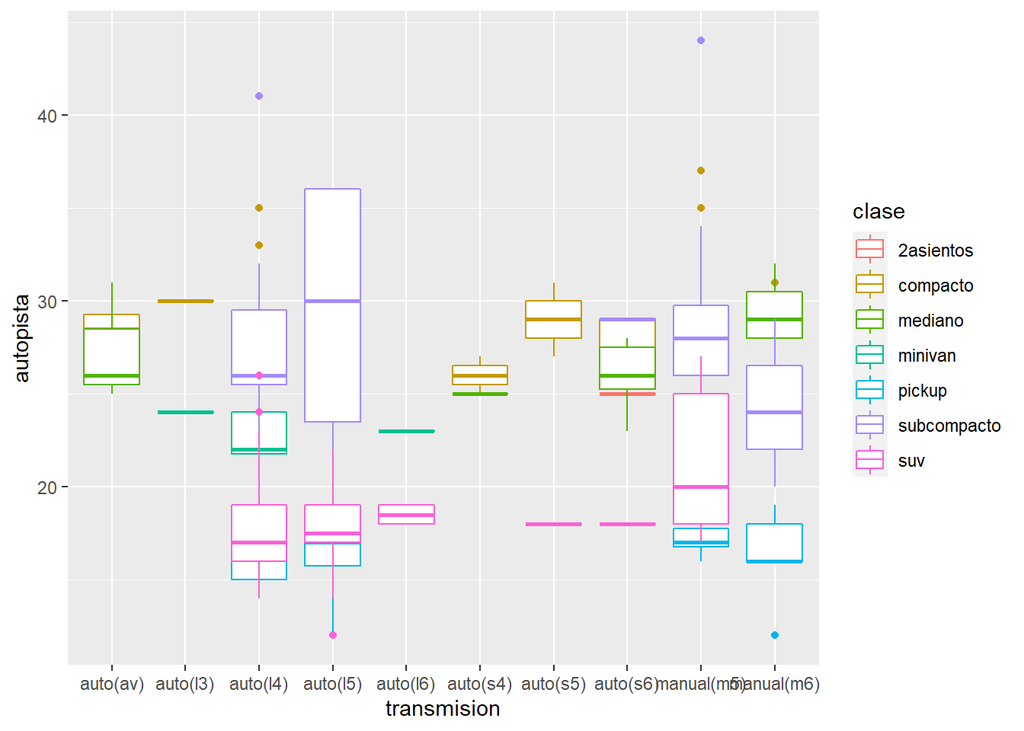

```r
ggplot(data = millas, aes(x = transmision, y = autopista, colour = clase)) +
  geom_boxplot(position = "identity")
```

# 10.7 Sistemas de coordenadas

Convierte un grafico de barras apiladas en un grafico circular usando `coord_polar()`.

Un grafico de torta es un grafico de barras aplicadas con la adicion de coordenadas polares.

Partamos del siguiente ejemplo:

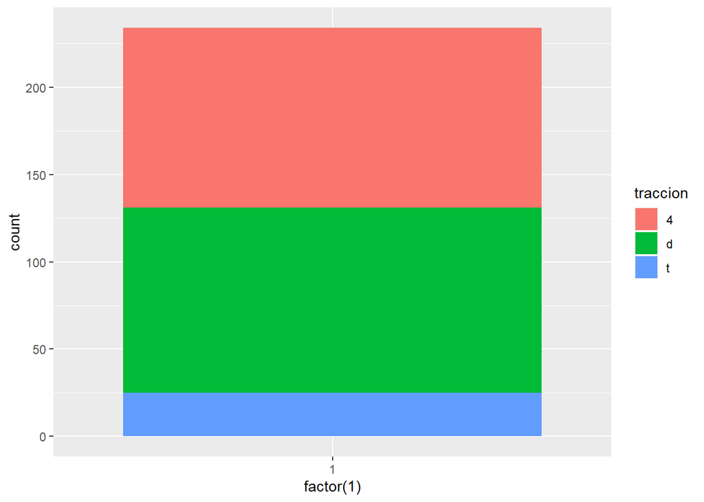

```r
ggplot(millas, aes(x = factor(1), fill = traccion)) +
geom_bar()
```

Ahora agregamos `coord_polar(theta="y")` para crear el grafico de torta:

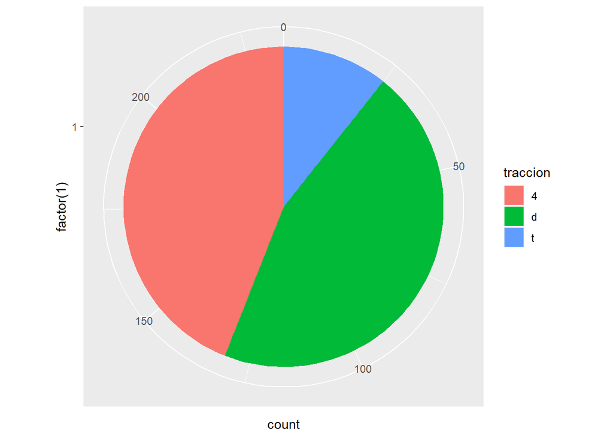

```r
ggplot(millas, aes(x = factor(1), fill = traccion)) +
geom_bar(width = 1) +
coord_polar(theta = "y")
```

El argumento `theta = "y"` transforma `y` en el angulo de cada seccion. Si `coord_polar()` se especifica sin `theta = "y"`, el resultado se llama “ojo de buey”.

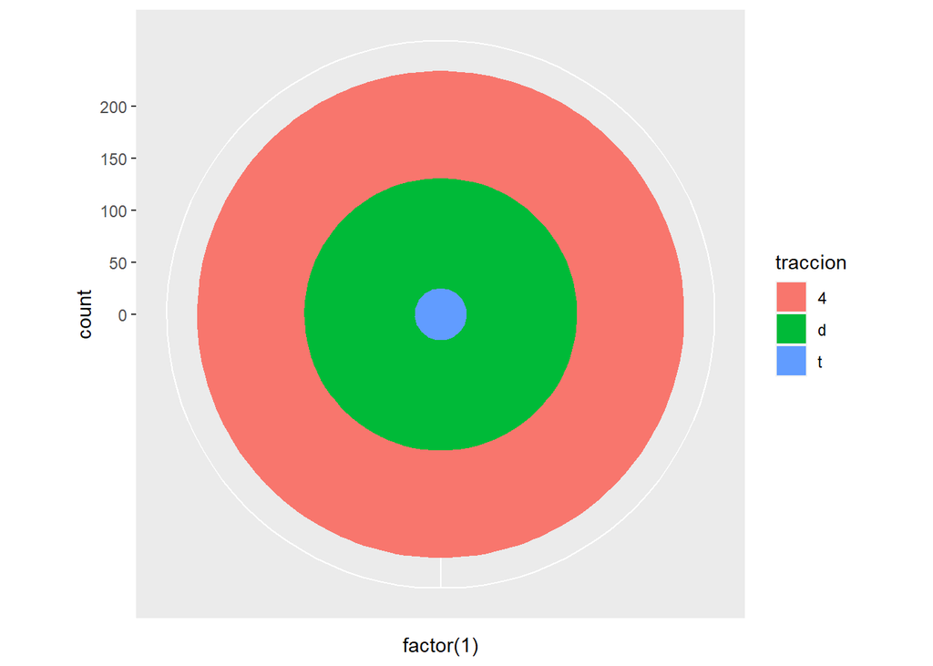

```r
ggplot(millas, aes(x = factor(1), fill = traccion)) +
  geom_bar(width = 1) +
  coord_polar()
```

¿Que hace `labs()`? Lee la documentacion. `labs` agrega los titulos de los ejes, titulo del grafico y la leyenda.

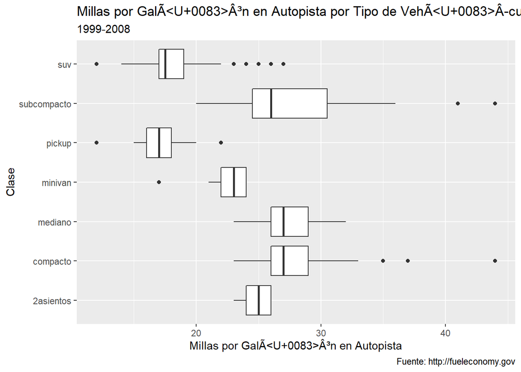

```r
ggplot(data = millas, mapping = aes(x = clase, y = autopista)) +
  geom_boxplot() +
  coord_flip() +
  labs(y = "Millas por GalÃÂ³n en Autopista",
       x = "Clase",
       title = "Millas por GalÃÂ³n en Autopista por Tipo de VehÃÂculo",
       subtitle = "1999-2008",
       caption = "Fuente: http://fueleconomy.gov")
```

`labs()` no es la unica funcion para agregar titulos. `xlab()`, `ylab()` y `ggtitle()` realizan la misma funcion.

¿Cual es la diferencia entre `coord_quickmap()` y `coord_map()`? `coord_map()` usa una proyeccion cartografica para proyectar la Tierra sobre una superficie bidimensional. Por defecto usa la [Proyeccion de Mercator](https://es.wikipedia.org/wiki/Proyecci%C3%B3n_de_Mercator), la cual se aplica a todas las geometrias del grafico.

`coord_quickmap()` usa una aproximacion mas rapida que ignora la curvatura de la tierra y ajusta de acuerdo a la razon de latitud y longitud. Esta es una alternativa computacionalmente mas rapida que no genera la necesidad de transformar las geometrias individuales.

Consulta [coord_map()](https://ggplot2.tidyverse.org/reference/coord_map.html) para la documentacion y ejemplos.

¿Que te dice la grafica siguiente sobre la relacion entre la ciudad y la `autopista`?¿Por que es `coord_fixed()` importante?¿Que hace `geom_abline()`?

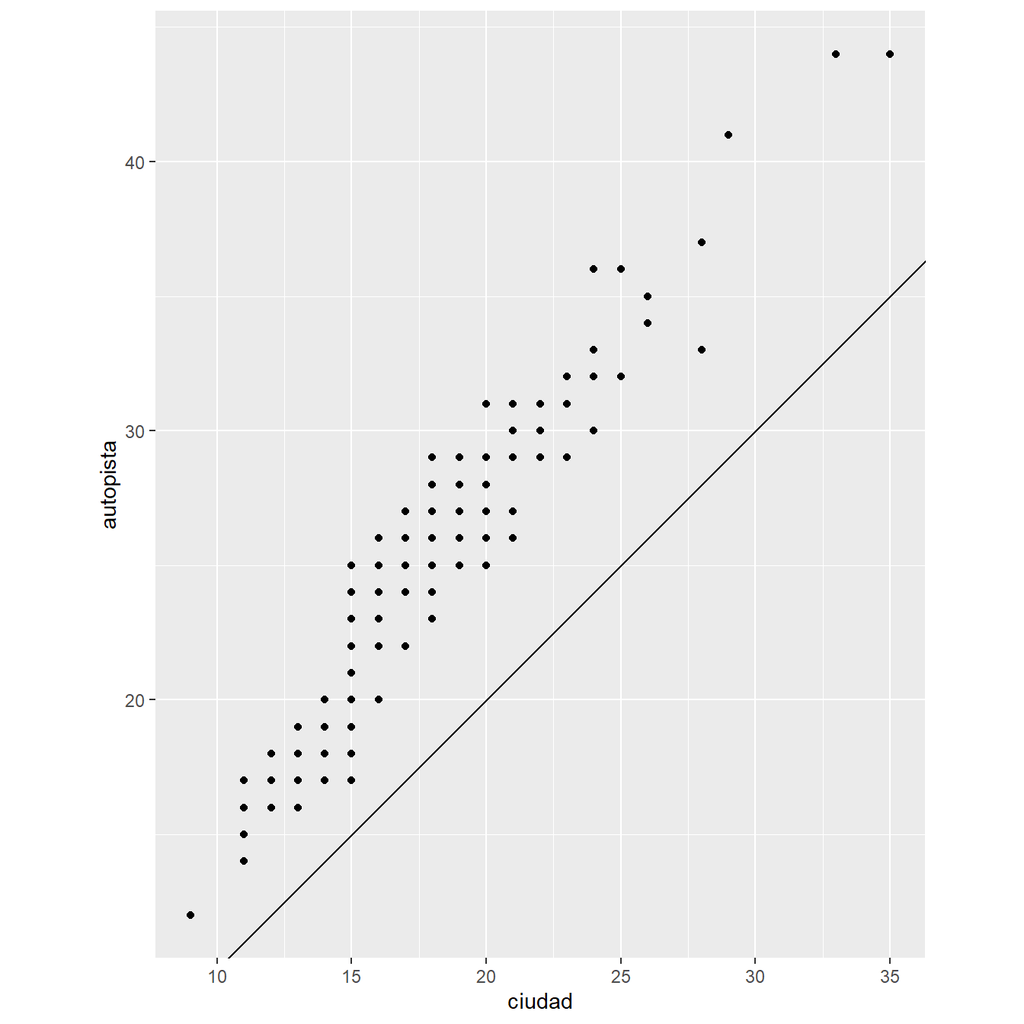

```r
ggplot(data = millas, mapping = aes(x = ciudad, y = autopista)) +
geom_point() +
geom_abline() +
coord_fixed()
```

La funcion `coord_fixed()` asegura que la linea que genera `geom_abline()` tenga un angulo de 45 grados. De este modo es mas facil comparar a partir de los casos en que los rendimientos en autopista y ciudad son iguales.

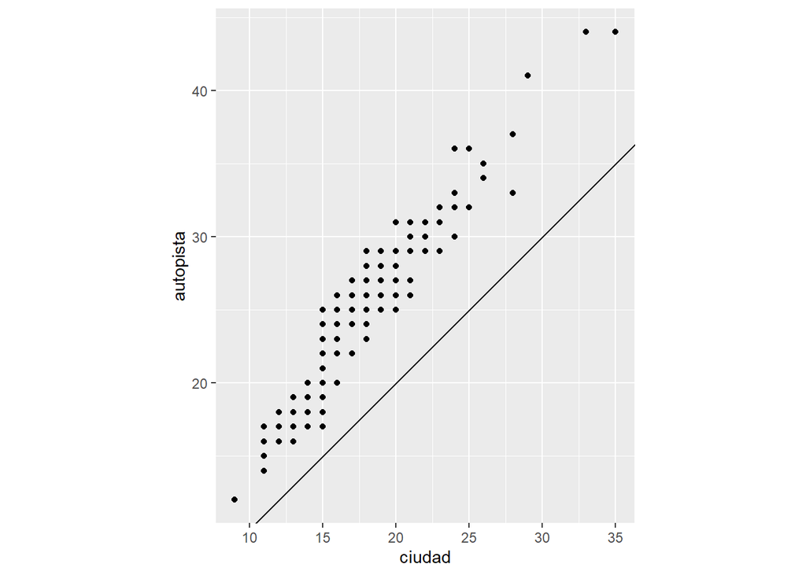

```r
ggplot(data = millas, mapping = aes(x = ciudad, y = autopista)) +
  geom_point() +
  geom_abline() +
  coord_fixed()
```

Lo que podemos ver es que en todos los modelos el rendimiento en autopista es superior al rendmiento en ciudad.